# 5

```python
from PIL import Image
import matplotlib.pyplot as plt
```

## Depth of the tree

```
Running training...
Trained 10 trees.

Applying the forest to test data...
Applied 10 trees.

Saving output image to result.dib
```

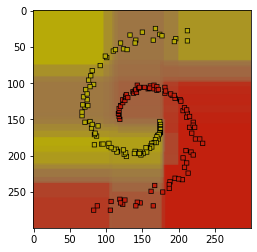

```python
!./sw class data/supervised\ classification/exp5_n2.txt /d 5
img = Image.open("result.dib")
plt.imshow(img)
```

```
Running training...
Trained 10 trees.

Applying the forest to test data...
Applied 10 trees.

Saving output image to result.dib
```

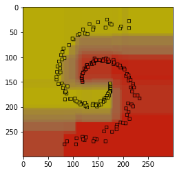

```python
!./sw class data/supervised\ classification/exp5_n2.txt /d 6
img = Image.open("result.dib")
plt.imshow(img)
```

```
Running training...
Trained 10 trees.

Applying the forest to test data...
Applied 10 trees.

Saving output image to result.dib
```

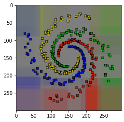

```python
!./sw class data/supervised\ classification/exp5_n4.txt /d 5
img = Image.open("result.dib")
plt.imshow(img)
```

```
Running training...
Trained 10 trees.

Applying the forest to test data...
Applied 10 trees.

Saving output image to result.dib
```

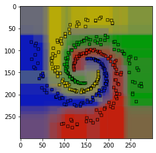

```python
!./sw class data/supervised\ classification/exp5_n4.txt /d 8
img = Image.open("result.dib")
plt.imshow(img)
```

For a classification problem with two classes we notice that the model with a maximum depth of 6 performs very good. For the problem with 4 classes we need a bigger depth (>=8) in order to have solid results.

## Number of trees

```
Running training...
Trained 1 trees.

Applying the forest to test data...
Applied 1 trees.

Saving output image to result.dib
```

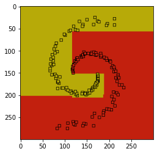

```python
!./sw class data/supervised\ classification/exp5_n2.txt /t 1
img = Image.open("result.dib")
plt.imshow(img)
```

```
Running training...
Trained 15 trees.

Applying the forest to test data...
Applied 15 trees.

Saving output image to result.dib
```

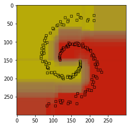

```python
!./sw class data/supervised\ classification/exp5_n2.txt /t 15
img = Image.open("result.dib")
plt.imshow(img)
```

```
Running training...
Trained 1 trees.

Applying the forest to test data...
Applied 1 trees.

Saving output image to result.dib
```

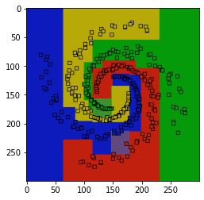

```python
!./sw class data/supervised\ classification/exp5_n4.txt /t 1
img = Image.open("result.dib")
plt.imshow(img)
```

```
Running training...
Trained 2 trees.

Applying the forest to test data...
Applied 2 trees.

Saving output image to result.dib
```

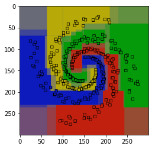

```python
!./sw class data/supervised\ classification/exp5_n4.txt /t 2
img = Image.open("result.dib")
plt.imshow(img)
```

```
Running training...
Trained 10 trees.

Applying the forest to test data...
Applied 10 trees.

Saving output image to result.dib
```

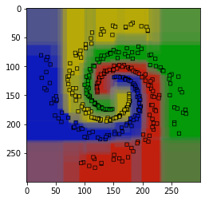

```python
!./sw class data/supervised\ classification/exp5_n4.txt /t 10
img = Image.open("result.dib")
plt.imshow(img)
```

We notice that when there is only one tree the boundaries are solid and are given from that one tree. As the number of trees becomes bigger, the boundaries formed from the multiple trees softens.

## Number of candidate feature response functions per split node

```
Running training...
Trained 10 trees.

Applying the forest to test data...
Applied 10 trees.

Saving output image to result.dib
```

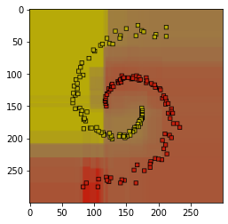

```python
!./sw class data/supervised\ classification/exp5_n2.txt /f 2
img = Image.open("result.dib")
plt.imshow(img)
```

```
Running training...
Trained 10 trees.

Applying the forest to test data...
Applied 10 trees.

Saving output image to result.dib
```

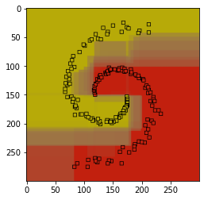

```python
!./sw class data/supervised\ classification/exp5_n2.txt /f 10
img = Image.open("result.dib")
plt.imshow(img)
```

```
Running training...
Trained 10 trees.

Applying the forest to test data...
Applied 10 trees.

Saving output image to result.dib
```

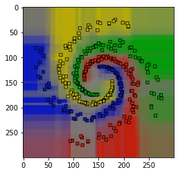

```python
!./sw class data/supervised\ classification/exp5_n4.txt /f 2
img = Image.open("result.dib")
plt.imshow(img)
```

```
Running training...
Trained 10 trees.

Applying the forest to test data...
Applied 10 trees.

Saving output image to result.dib
```

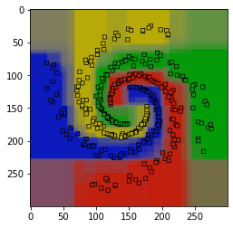

```python
!./sw class data/supervised\ classification/exp5_n4.txt /f 15
img = Image.open("result.dib")
plt.imshow(img)
```

Having more candidate feature response functions means that each node has better chance to pick the optimal response function. The same goes for the next hyperparameter which is the number of candidate thresholds per feature response function

## Number of candidate thresholds per feature response function

```
Running training...
Trained 10 trees.

Applying the forest to test data...
Applied 10 trees.

Saving output image to result.dib
```

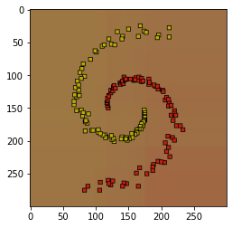

```python
!./sw class data/supervised\ classification/exp5_n2.txt /l 1 /f 1
img = Image.open("result.dib")
plt.imshow(img)
```

```
Running training...
Trained 10 trees.

Applying the forest to test data...
Applied 10 trees.

Saving output image to result.dib
```

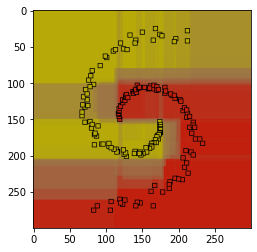

```python
!./sw class data/supervised\ classification/exp5_n2.txt /l 15 /f 1
img = Image.open("result.dib")
plt.imshow(img)
```

```
Running training...
Trained 10 trees.

Applying the forest to test data...
Applied 10 trees.

Saving output image to result.dib
```

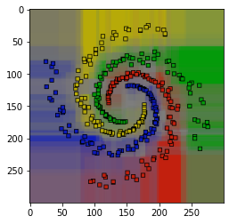

```python
!./sw class data/supervised\ classification/exp5_n4.txt /l 2 /f 1
img = Image.open("result.dib")
plt.imshow(img)
```

```
Running training...
Trained 10 trees.

Applying the forest to test data...
Applied 10 trees.

Saving output image to result.dib
```

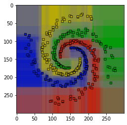

```python
!./sw class data/supervised\ classification/exp5_n4.txt /l 20 /f 1
img = Image.open("result.dib")
plt.imshow(img)
```

By leaving the number of candidate feature response functions high, this hyperparameter does not have a big influence. However, if we lower the number of candidate response functions, this hyperparameter gives the ability to pick the best threshold for the limited candidates there are per node.